# Tugas Praktikum 5

Nazuwa Aulia

2023-09-26

# Library yang akan digunakan

```r
library(ggplot2)
library(tsibble)
library(tseries)
library(MASS)
library(readxl)
library(rio)
```

# Import Data

```r
data <- import("https://raw.githubusercontent.com/nazuwaaulia/MPDW/main/Pertemuan%201/dataset.csv")
data
```

```
##               date rate
## 1        Juli 2013  7.3
## 2     Agustus 2013  7.2
## 3   September 2013  7.2
## 4     Oktober 2013  7.2
## 5    November 2013  6.9
## 6    Desember 2013  6.7
## 7     Januari 2014  6.6
## 8    Februari 2014  6.7
## 9       Maret 2014  6.7
## 10      April 2014  6.2
## 11        Mei 2014  6.3
## 12       Juni 2014  6.1
## 13       Juli 2014  6.2
## 14    Agustus 2014  6.1
```

[output cut: 107 more lines]

```r
rate <- ts(data$rate)
```

## Data Penuh

### Plot Time Series

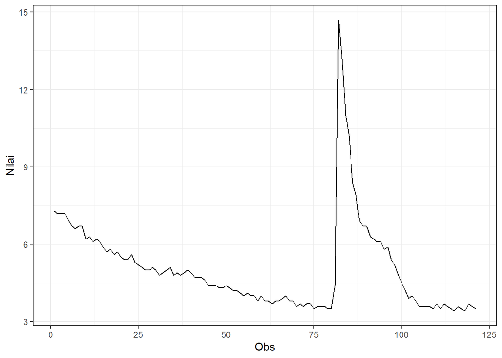

```r
plot_stas <- rate |> as_tsibble() |>
  ggplot(aes(x = index, y = value)) + geom_line() + theme_bw() +
  xlab("Obs") + ylab("Nilai")
plot_stas
```

```r
mean(rate)
```

```
## [1] 5.052066
```

Plot deret waktu di atas menunjukkan bahwa data tidak stasioner dalam rataan dan tidak stasioner dalam ragam. Dari plot deret waktu diatas dapat dilihat data cenderung membentuk pola trend

### Plot ACF

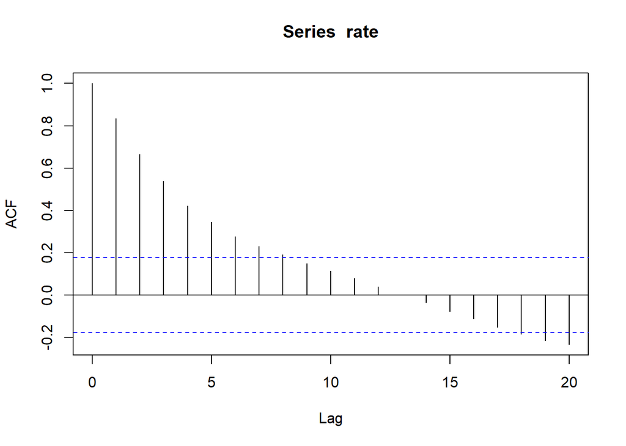

```r
acf(rate)
```

Berdasarkan plot ACF, terlihat bahwa plot ACF pada data tersebut cenderung *tails off* yaitu lag menurun secara lambat dan membentuk gelombang sinus. Sehingga dapat disimpulkan bahwa data tidak stasioner dalam rataan

### Uji ADF

```r
tseries::adf.test(rate)
```

```
##
##  Augmented Dickey-Fuller Test
##
## data:  rate
## Dickey-Fuller = -2.8421, Lag order = 4, p-value = 0.2268
## alternative hypothesis: stationary
```

$H_0$ : Data tidak stasioner dalam rataan

$H_1$ : Data stasioner dalam rataan

Berdasarkan uji ADF tersebut, didapat *p-value* sebesar 0.2268 yang lebih besar dari taraf nyata 5% sehingga tak tolak $H_0$ dan menandakan bahwa data tersebut tidak stasioner dalam rataan. Hal ini sesuai dengan hasil eksplorasi menggunakan plot time series dan plot ACF.

### Plot Box-Cox

digunakan untuk mengecek ke stasioneran dalam ragam

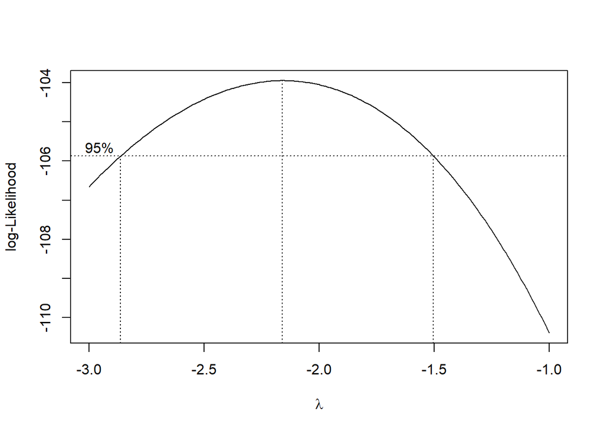

```r
index <- seq(1:121)
bc = boxcox(rate~index, lambda = seq(-3,-1,by=0.01))
```

```r
#Nilai Rounded Lambda
lambda <- bc$x[which.max(bc$y)]
lambda
```

```
## [1] -2.16
```

```r
#SK
bc$x[bc$y > max(bc$y) - 1/2 * qchisq(.95,1)]
```

```
##   [1] -2.86 -2.85 -2.84 -2.83 -2.82 -2.81 -2.80 -2.79 -2.78 -2.77 -2.76 -2.75
##  [13] -2.74 -2.73 -2.72 -2.71 -2.70 -2.69 -2.68 -2.67 -2.66 -2.65 -2.64 -2.63
##  [25] -2.62 -2.61 -2.60 -2.59 -2.58 -2.57 -2.56 -2.55 -2.54 -2.53 -2.52 -2.51
##  [37] -2.50 -2.49 -2.48 -2.47 -2.46 -2.45 -2.44 -2.43 -2.42 -2.41 -2.40 -2.39
##  [49] -2.38 -2.37 -2.36 -2.35 -2.34 -2.33 -2.32 -2.31 -2.30 -2.29 -2.28 -2.27
##  [61] -2.26 -2.25 -2.24 -2.23 -2.22 -2.21 -2.20 -2.19 -2.18 -2.17 -2.16 -2.15
##  [73] -2.14 -2.13 -2.12 -2.11 -2.10 -2.09 -2.08 -2.07 -2.06 -2.05 -2.04 -2.03
##  [85] -2.02 -2.01 -2.00 -1.99 -1.98 -1.97 -1.96 -1.95 -1.94 -1.93 -1.92 -1.91
##  [97] -1.90 -1.89 -1.88 -1.87 -1.86 -1.85 -1.84 -1.83 -1.82 -1.81 -1.80 -1.79
## [109] -1.78 -1.77 -1.76 -1.75 -1.74 -1.73 -1.72 -1.71 -1.70 -1.69 -1.68 -1.67
## [121] -1.66 -1.65 -1.64 -1.63 -1.62 -1.61 -1.60 -1.59 -1.58 -1.57 -1.56 -1.55
## [133] -1.54 -1.53 -1.52 -1.51
```

Gambar di atas menunjukkan nilai *rounded value* ($\lambda$) optimum sebesar **-2.16** dan pada selang kepercayaan 95% nilai memiliki batas bawah **-2.86** dan batas atas **-1.51**. Selang tersebut tidak memuat nilai satu sehingga dapat dikatakan bahwa data tidak stasioner dalam ragam.

## Partisi Data

### Bagian 1

```r
dt_stas1 <- rate[1:40] |> ts()
mean(dt_stas1)
```

```
## [1] 5.72
```

```r
var(dt_stas1)
```

```
## [1] 0.6395897
```

#### Plot Time Series

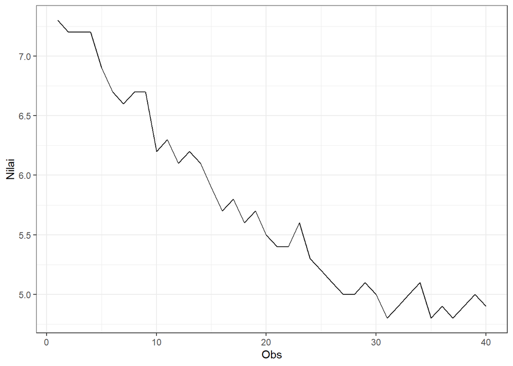

```r
dt_stas1 |> as_tsibble() |>
  ggplot(aes(x = index, y = value)) +
  geom_line() + theme_bw() +
  xlab("Obs") + ylab("Nilai")
```

Plot deret waktu di atas menunjukkan bahwa data tidak stasioner dalam rataan dan tidak stasioner dalam ragam. Dari plot deret waktu diatas dapat dilihat data cenderung membentuk pola trend

#### Plot ACF

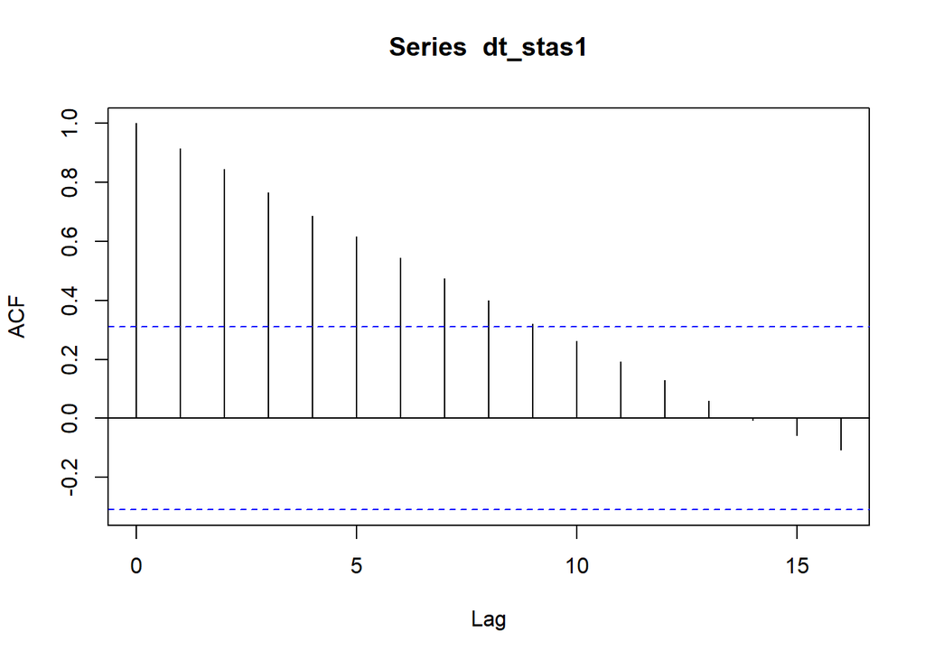

```r
acf(dt_stas1)
```

Berdasarkan plot ACF, terlihat bahwa plot ACF pada data tersebut cenderung *tails off* yaitu lag menurun secara lambat dan membentuk gelombang sinus. Sehingga dapat disimpulkan bahwa data tidak stasioner dalam rataan

#### Uji ADF

```r
tseries::adf.test(dt_stas1)
```

```
##
##  Augmented Dickey-Fuller Test
##
## data:  dt_stas1
## Dickey-Fuller = -0.31722, Lag order = 3, p-value = 0.9849
## alternative hypothesis: stationary
```

$H_0$ : Data tidak stasioner dalam rataan

$H_1$ : Data stasioner dalam rataan

Berdasarkan uji ADF tersebut, didapat *p-value* sebesar 0.9849 yang lebih besar dari taraf nyata 5% sehingga tak tolak $H_0$ dan menandakan bahwa data tidak stasioner dalam rataan. Hal ini sesuai dengan hasil eksplorasi menggunakan plot time series dan plot ACF.

#### Plot Box-cox

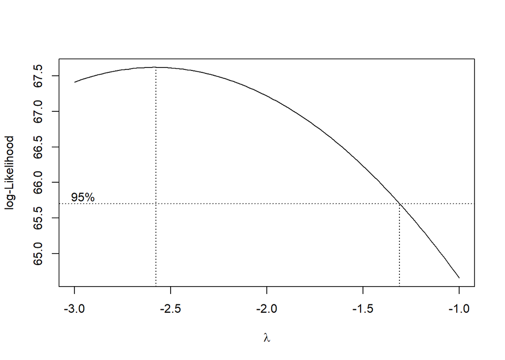

```r
index <- seq(1:40)
bc = boxcox(dt_stas1~index, lambda = seq(-3,-1,by=1))
```

```r
#Nilai Rounded Lambda
lambda <- bc$x[which.max(bc$y)]
lambda
```

```
## [1] -2.575758
```

```r
#SK
bc$x[bc$y > max(bc$y) - 1/2 * qchisq(.95,1)]
```

```
##  [1] -3.000000 -2.979798 -2.959596 -2.939394 -2.919192 -2.898990 -2.878788
##  [8] -2.858586 -2.838384 -2.818182 -2.797980 -2.777778 -2.757576 -2.737374
## [15] -2.717172 -2.696970 -2.676768 -2.656566 -2.636364 -2.616162 -2.595960
## [22] -2.575758 -2.555556 -2.535354 -2.515152 -2.494949 -2.474747 -2.454545
## [29] -2.434343 -2.414141 -2.393939 -2.373737 -2.353535 -2.333333 -2.313131
## [36] -2.292929 -2.272727 -2.252525 -2.232323 -2.212121 -2.191919 -2.171717
## [43] -2.151515 -2.131313 -2.111111 -2.090909 -2.070707 -2.050505 -2.030303
## [50] -2.010101 -1.989899 -1.969697 -1.949495 -1.929293 -1.909091 -1.888889
## [57] -1.868687 -1.848485 -1.828283 -1.808081 -1.787879 -1.767677 -1.747475
## [64] -1.727273 -1.707071 -1.686869 -1.666667 -1.646465 -1.626263 -1.606061
## [71] -1.585859 -1.565657 -1.545455 -1.525253 -1.505051 -1.484848 -1.464646
## [78] -1.444444 -1.424242 -1.404040 -1.383838 -1.363636 -1.343434 -1.323232
```

Gambar di atas menunjukkan nilai *rounded value* ($\lambda$) optimum sebesar **-2.575758** dan pada selang kepercayaan 95% nilai memiliki batas bawah **-3.000000** dan batas atas **-1.323232**. Selang tersebut tidak memuat nilai satu sehingga dapat dikatakan bahwa data tidak stasioner dalam ragam.

### Bagian 2

```r
dt_stas2 <- rate[1:80] |> ts()
mean(dt_stas2)
```

```
## [1] 4.855
```

```r
var(dt_stas2)
```

```
## [1] 1.13719
```

#### Plot Time Series

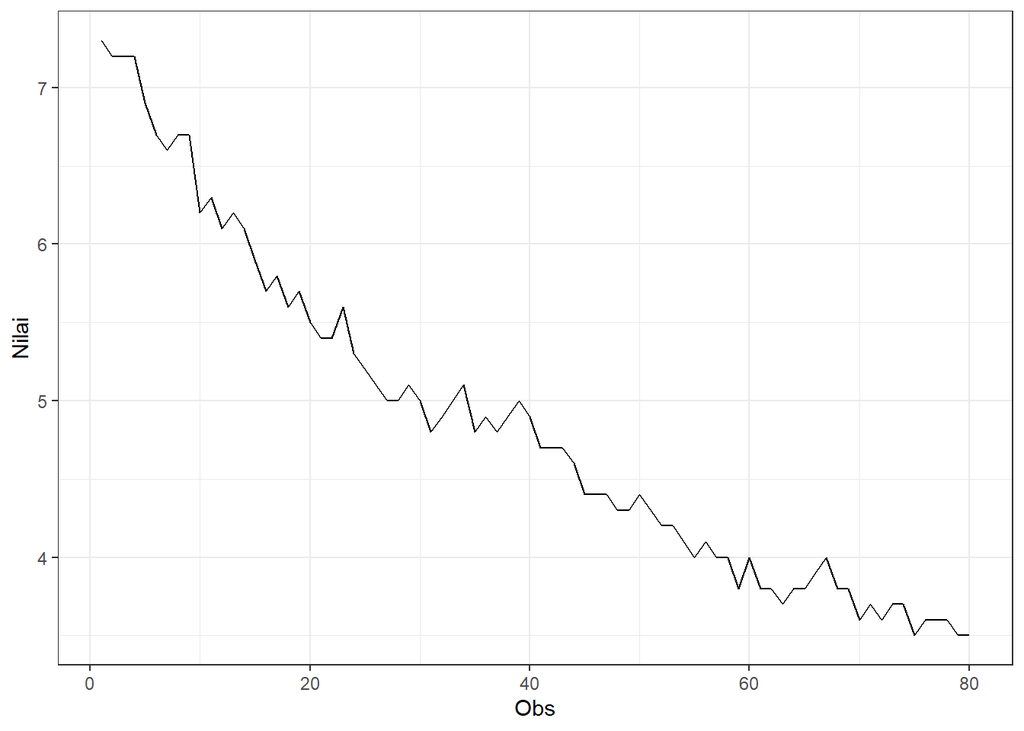

```r
dt_stas2 |> as_tsibble() |>
  ggplot(aes(x = index, y = value)) +
  geom_line() + theme_bw() +
  xlab("Obs") + ylab("Nilai")
```

Plot deret waktu di atas menunjukkan bahwa data tidak stasioner dalam rataan dan tidak stasioner dalam ragam. Dari plot deret waktu diatas dapat dilihat data cenderung membentuk pola trend

#### Plot ACF

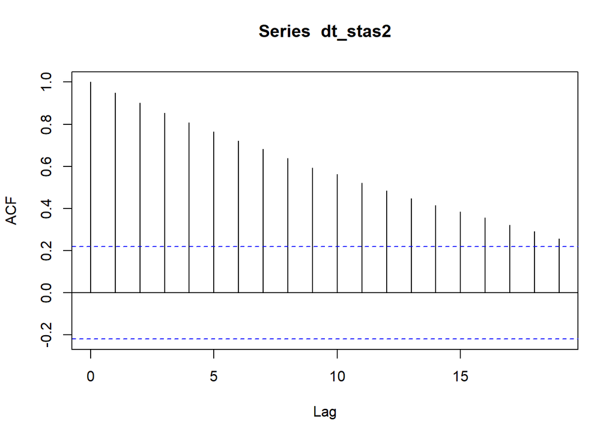

```r
acf(dt_stas2)
```

Berdasarkan plot ACF, terlihat bahwa plot ACF pada data tersebut cenderung *tails off* yaitu lag menurun secara lambat sehingga dapat disimpulkan bahwa data tidak stasioner dalam rataan

#### Uji ADF

```r
adf.test(dt_stas2)
```

```
##
##  Augmented Dickey-Fuller Test
##
## data:  dt_stas2
## Dickey-Fuller = -2.9993, Lag order = 4, p-value = 0.1668
## alternative hypothesis: stationary
```

$H_0$ : Data tidak stasioner dalam rataan

$H_1$ : Data stasioner dalam rataan

Berdasarkan uji ADF tersebut, didapat *p-value* sebesar 0.1668 yang lebih besar dari taraf nyata 5% sehingga tak tolak $H_0$ dan menandakan bahwa data tidak stasioner dalam rataan. Hal ini sesuai dengan hasil eksplorasi menggunakan plot time series dan plot ACF.

#### Plot Box-cox

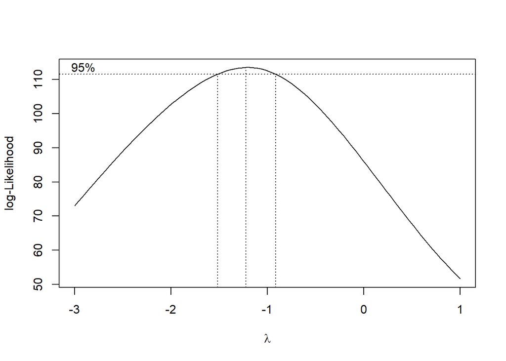

```r
index <- seq(1:80)
bc = boxcox(dt_stas2~index, lambda = seq(-3,1,by=1))
```

```r
#Nilai Rounded Lambda
lambda <- bc$x[which.max(bc$y)]
lambda
```

```
## [1] -1.222222
```

```r
#SK
bc$x[bc$y > max(bc$y) - 1/2 * qchisq(.95,1)]
```

```
##  [1] -1.5050505 -1.4646465 -1.4242424 -1.3838384 -1.3434343 -1.3030303
##  [7] -1.2626263 -1.2222222 -1.1818182 -1.1414141 -1.1010101 -1.0606061
## [13] -1.0202020 -0.9797980 -0.9393939
```

Gambar di atas menunjukkan nilai *rounded value* ($\lambda$) optimum sebesar **-1.222222** dan pada selang kepercayaan 95% nilai memiliki batas bawah **-1.5050505** dan batas atas **-0.9393939**. Selang tersebut tidak memuat nilai satu sehingga dapat dikatakan bahwa data tidak stasioner dalam ragam.

# Kesimpulan

Berdasarkan analisis yang dilakukan pada data penuh, data partisi 1 dan data partisi 2 dapat disimpulkan bahwa data tidak stasioner dalam rataan maupun dalam ragam. Analisis dilakukan dengan cara menguji kestasioneran dalam rataan menggunakan plot ACF dan uji ADF sedangkan untuk menguji kestasioneran dalam ragam menggunakan plot Box-cox.